# Allhomework

1. In this part, we generate the samples from two populations, which has unequal variances and equal expectations( both expectations are $0$).

```r
library(energy)

library(Ball)
library(RANN)
set.seed(1234)
m <- 1e2; k<-3; p<-2; mu <- 0; set.seed(12345)
n1 <- n2 <- 50; R<-999; n <- n1+n2; N = c(n1,n2)
Tn <- function(z, ix, sizes,k) {
n1 <- sizes[1]; n2 <- sizes[2]; n <- n1 + n2
if(is.vector(z)) z <- data.frame(z,0);
z <- z[ix, ];
NN <- nn2(data=z, k=k+1) # what's the first column?
block1 <- NN$nn.idx[1:n1,-1]
block2 <- NN$nn.idx[(n1+1):n,-1]
i1 <- sum(block1 < n1 + .5); i2 <- sum(block2 > n1+.5)
(i1 + i2) / (k * n)
}


eqdist.nn <- function(z,sizes,k){
boot.obj <- boot(data=z,statistic=Tn,R=R,
sim = "permutation", sizes = sizes,k=k)
ts <- c(boot.obj$t0,boot.obj$t)
p.value <- mean(ts>=ts[1])
list(statistic=ts[1],p.value=p.value)
}
p.values <- matrix(NA,m,3)
for(i in 1:m){
x <- matrix(rnorm(n1*p,0,1.7),ncol=p);
y <- cbind(rnorm(n2),rnorm(n2,mean=mu,1.5));
z <- rbind(x,y)
p.values[i,1] <- eqdist.nn(z,N,k)$p.value
p.values[i,2] <- eqdist.etest(z,sizes=N,R=R)$p.value
p.values[i,3] <- bd.test(x=x,y=y,num.permutations=999,seed=i*1235)$p.value
}
alpha <- 0.1;
pow <- colMeans(p.values<alpha)
NNpower=pow[1]
energypower=pow[2]
bdpower=pow[3]
result=cbind(NNpower,energypower,bdpower)
x_html=knitr::kable((result),"html")
kableExtra::kable_styling(x_html,bootstrap_options = "hover",full_width = TRUE,font_size=12)
```

| NNpower | energypower | bdpower |
| --- | --- | --- |
| 0.46 | 0.41 | 0.79 |

2. In this part, we generate the samples from two populations, which has unequal variances and unequal expectations.

```r
library(energy)
library(Ball)
library(RANN)
set.seed(124)
m <- 1e2; k<-3; p<-2; mu <- .5; set.seed(12345)
n1 <- n2 <- 50; R<-999; n <- n1+n2; N = c(n1,n2)
Tn <- function(z, ix, sizes,k) {
n1 <- sizes[1]; n2 <- sizes[2]; n <- n1 + n2
if(is.vector(z)) z <- data.frame(z,0);
z <- z[ix, ];
NN <- nn2(data=z, k=k+1) # what's the first column?
block1 <- NN$nn.idx[1:n1,-1]
block2 <- NN$nn.idx[(n1+1):n,-1]
i1 <- sum(block1 < n1 + .5); i2 <- sum(block2 > n1+.5)
(i1 + i2) / (k * n)
}


eqdist.nn <- function(z,sizes,k){
boot.obj <- boot(data=z,statistic=Tn,R=R,
sim = "permutation", sizes = sizes,k=k)
ts <- c(boot.obj$t0,boot.obj$t)
p.value <- mean(ts>=ts[1])
list(statistic=ts[1],p.value=p.value)
}
p.values <- matrix(NA,m,3)
for(i in 1:m){
x <- matrix(rnorm(n1*p,0,1.5),ncol=p);
y <- cbind(rnorm(n2,0.2,1.3),rnorm(n2,mean=mu,1.4));
z <- rbind(x,y)
p.values[i,1] <- eqdist.nn(z,N,k)$p.value
p.values[i,2] <- eqdist.etest(z,sizes=N,R=R)$p.value
p.values[i,3] <- bd.test(x=x,y=y,num.permutations=999,seed=i*12345)$p.value
}
alpha <- 0.1;
pow <- colMeans(p.values<alpha)
NNpower=pow[1]
energypower=pow[2]
bdpower=pow[3]
result=cbind(NNpower,energypower,bdpower)
x_html=knitr::kable((result),"html")
kableExtra::kable_styling(x_html,bootstrap_options = "hover",full_width = TRUE,font_size=12)
```

| NNpower | energypower | bdpower |
| --- | --- | --- |
| 0.28 | 0.59 | 0.53 |

3. In this part, we generate the samples from two t distribution with 1 df (heavy-tailed distribution) and bimodel distribution (mixture of two normal distributions).

```r
library(energy)
library(Ball)
library(RANN)
set.seed(1234)
m <- 1e2; k<-3; p<-2; mu <- .5; set.seed(12345)
n1 <- n2 <- 50; R<-999; n <- n1+n2; N = c(n1,n2)
Tn <- function(z, ix, sizes,k) {
n1 <- sizes[1]; n2 <- sizes[2]; n <- n1 + n2
if(is.vector(z)) z <- data.frame(z,0);
z <- z[ix, ];
NN <- nn2(data=z, k=k+1) # what's the first column?
block1 <- NN$nn.idx[1:n1,-1]
block2 <- NN$nn.idx[(n1+1):n,-1]
i1 <- sum(block1 < n1 + .5); i2 <- sum(block2 > n1+.5)
(i1 + i2) / (k * n)
}
rbimodel=function(n,mean1,sd1,mean2,sd2,pro){
   p=sample(c(1,0),n,replace = TRUE,prob=c(pro,1-pro))
  x=p*rnorm(n,mean1,sd1)+(1-p)*rnorm(n,mean2,sd2)
  return(x)
}

eqdist.nn <- function(z,sizes,k){
boot.obj <- boot(data=z,statistic=Tn,R=R,
sim = "permutation", sizes = sizes,k=k)
ts <- c(boot.obj$t0,boot.obj$t)
p.value <- mean(ts>=ts[1])
list(statistic=ts[1],p.value=p.value)
}
p.values <- matrix(NA,m,3)
for(i in 1:m){
x <- matrix(rt(n1*p,df=1),ncol=p);
y <- cbind(rbimodel(n1,-1,1,1,2,0.5),rbimodel(n2,-1,1,1,2,0.5))
z <- rbind(x,y)
p.values[i,1] <- eqdist.nn(z,N,k)$p.value
p.values[i,2] <- eqdist.etest(z,sizes=N,R=R)$p.value
p.values[i,3] <- bd.test(x=x,y=y,num.permutations=999,seed=i*12345)$p.value
}
alpha <- 0.1;
pow <- colMeans(p.values<alpha)
NNpower=pow[1]
energypower=pow[2]
bdpower=pow[3]
result=cbind(NNpower,energypower,bdpower)
x_html=knitr::kable((result),"html")
kableExtra::kable_styling(x_html,bootstrap_options = "hover",full_width = TRUE,font_size=12)
```

| NNpower | energypower | bdpower |
| --- | --- | --- |
| 0.69 | 0.79 | 0.75 |

4. In this part, we generate the samples from two unbalanced population ($n(X)=2n(Y)).

```r
library(energy)
library(Ball)
library(RANN)
set.seed(1234)
m <- 1e2; k<-3; p<-2; mu <- .5; set.seed(12345)
n1 <- 100;n2 <- 50; R<-999; n <- n1+n2; N = c(n1,n2)
Tn <- function(z, ix, sizes,k) {
n1 <- sizes[1]; n2 <- sizes[2]; n <- n1 + n2
if(is.vector(z)) z <- data.frame(z,0);
z <- z[ix, ];
NN <- nn2(data=z, k=k+1) # what's the first column?
block1 <- NN$nn.idx[1:n1,-1]
block2 <- NN$nn.idx[(n1+1):n,-1]
i1 <- sum(block1 < n1 + .5); i2 <- sum(block2 > n1+.5)
(i1 + i2) / (k * n)
}
rbimodel=function(n,mean1,sd1,mean2,sd2,pro){
   p=sample(c(1,0),n,replace = TRUE,prob=c(pro,1-pro))
  x=p*rnorm(n,mean1,sd1)+(1-p)*rnorm(n,mean2,sd2)
  return(x)
}

eqdist.nn <- function(z,sizes,k){
boot.obj <- boot(data=z,statistic=Tn,R=R,
sim = "permutation", sizes = sizes,k=k)
ts <- c(boot.obj$t0,boot.obj$t)
p.value <- mean(ts>=ts[1])
list(statistic=ts[1],p.value=p.value)
}
p.values <- matrix(NA,m,3)
for(i in 1:m){
x <- matrix(rnorm(n1*p,0,1.5),ncol=p);
y <- cbind(rnorm(n2,0.2,1.3),rnorm(n2,mean=mu,1.4));
z <- rbind(x,y)
p.values[i,1] <- eqdist.nn(z,N,k)$p.value
p.values[i,2] <- eqdist.etest(z,sizes=N,R=R)$p.value
p.values[i,3] <- bd.test(x=x,y=y,num.permutations=999,seed=i*12345)$p.value
}
alpha <- 0.1;
pow <- colMeans(p.values<alpha)
NNpower=pow[1]
energypower=pow[2]
bdpower=pow[3]
result=cbind(NNpower,energypower,bdpower)
x_html=knitr::kable((result),"html")
kableExtra::kable_styling(x_html,bootstrap_options = "hover",full_width = TRUE,font_size=12)
```

| NNpower | energypower | bdpower |
| --- | --- | --- |
| 0.22 | 0.51 | 0.53 |

##Homework 8

##9.3

Use the Metropolis-Hastings sampler to generate random variables from a standard Cauchy distribution. Discard the first 1000 of the chain, and compare the deciles of the generated observations with the deciles of the standard Cauchy distribution (see qcauchy or qt with df=1). Recall that a $Cauchy(\theta, \eta)$ distribution has density function
$$f(x)=\frac{\theta}{\pi[\theta^2+(x-\eta)^2]},-\infty<x<\infty,~\theta>0$$
The standard Cauchy has the Cauchy($\theta$ = 1, $\theta$ = 0) density. (Note that the standard Cauchy density is equal to the Student t density with one degree of freedom.)

##Answer

We choose $N(X_t,\sigma^2)$ as proposal distribution and use Metroplis-method to generate random variables from standard Cauchy distribution ($C(0,1)$). $\sigma$ is set as different values to find the optimal chain.

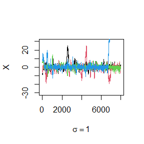

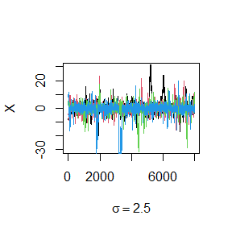

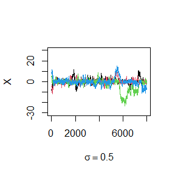

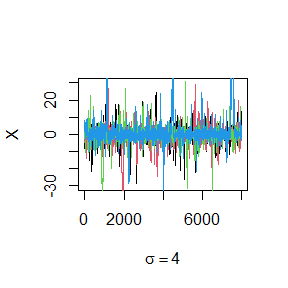

```r
set.seed(123)
 Gelman.Rubin <- function(psi) {
        # psi[i,j] is the statistic psi(X[i,1:j])
        # for chain in i-th row of X
        psi <- as.matrix(psi)
        n <- ncol(psi)
        k <- nrow(psi)

        psi.means <- rowMeans(psi)     #row means
        B <- n * var(psi.means)        #between variance est.
        psi.w <- apply(psi, 1, "var")  #within variances
        W <- mean(psi.w)               #within est.
        v.hat <- W*(n-1)/n + B/n+(B/(n*k))     #upper variance est.
        r.hat <- v.hat / W             #G-R statistic
        return(r.hat)
        }
rw.Metropolis <- function(n, sigma, x0, N) {
       # n: degree of freedom of t distribution
       # sigma:  standard variance of proposal distribution N(xt,sigma)
       # x0: initial value
       # N: size of random numbers required.
        x <- numeric(N)
        x[1] <- x0
        u <- runif(N)
        k <- 0
        for (i in 2:N) {
            y <- rnorm(1, x[i-1], sigma)
                if (u[i] <= (dt(y, n) / dt(x[i-1], n)))
                    x[i] <- y
                else {
                    x[i] <- x[i-1]
                    k <- k + 1
                }
            }
        return(list(x=x, k=k))
}
N<- 8000     #length of chains
n=1
b <- 1000       #burn-in length
x0 <- c(-8, -5, 5, 8)
k=4
sigma=c(1,2.5,0.5,4)
X <- matrix(0, nrow=k, ncol=N)
 par(mfrow=c(1,1))
for(j in 1:4){
      for (i in 1:k){
        X[i, ] <- rw.Metropolis(n,sigma[j], x0[i],N)$x}
    #trace plots
     plot(1:N,X[1,],type="l",ylim=c(-30,30),xlab=bquote(sigma == .(round(sigma[j],3))),
             ylab="X")
     lines(1:N,X[2,],type="l",col=2)
     lines(1:N,X[3,],type="l",col=3)
     lines(1:N,X[4,],type="l",col=4)}
```

```r
xt<- matrix(0, nrow=k, ncol=N)
for (i in 1:k){
        xt[i, ] <- rw.Metropolis(n,1, x0[i],N)$x}
psi <- t(apply(xt, 1, cumsum))
for (i in 1:nrow(psi)){psi[i,] <- psi[i,] / (1:ncol(psi))}

print(Gelman.Rubin(psi))
```

```
## [1] 1.109453
```

We can find that $\hat{R}$ is less than 1.2, which means that this chain converges very fast. Finally, we compare the deciles of the generated observations with the deciles of the standard Cauchy distribution.

```r
par(mfrow=c(1,1)) #reset to default
 a<- c(.05,seq(.1,.9,.1),.95)
    Q<- qt(a,n)

    mc<-cbind(xt[2,1001:N])
    Qrw<- apply(mc, 2,function(x) quantile(x,a))
    x_html=knitr::kable((round(cbind(Q, Qrw), 3)),"html")
   kableExtra::kable_styling(x_html,bootstrap_options = "hover",full_width = TRUE,font_size=12)
```

|  | Q |  |
| --- | --- | --- |
| 5% | -6.314 | -3.865 |
| 10% | -3.078 | -2.504 |
| 20% | -1.376 | -1.200 |
| 30% | -0.727 | -0.620 |
| 40% | -0.325 | -0.263 |
| 50% | 0.000 | 0.047 |
| 60% | 0.325 | 0.367 |
| 70% | 0.727 | 0.777 |
| 80% | 1.376 | 1.380 |
| 90% | 3.078 | 2.847 |
| 95% | 6.314 | 5.284 |

##9.8

This example appears in [40]. Consider the bivariate density,
$$f(x,y)\propto\binom{n}{x}y^{x+a-1}(1-y)^{n-x+b-1}~x=1...n~0\leqslant y\leqslant 1$$
It can be shown (see e.g. [23]) that for fixed a, b, n, the conditional distributions are Binomiall$(n, y)$ and Beta$(x + a, n − x + b)$. Use the Gibbs sampler to generate a chain with target joint density $f(x, y)$.

##Answer

Set $a=2,b=4,n=16$, then use Gibbs method to generate a chain with target joint density $f(x, y)$.

```r
set.seed(123)
N <- 12000
index=1:N
burn <- 1000            #burn-in length
x0=rbind(c(5,0.6),c(6,0.7),c(7,0.8),c(8,0.5))
fxy=function(N,x0){
x<- matrix(0, N, 2)
x[1,]=x0
for (i in 2:N) {

         x[i,1]=rbinom(1,size=16,prob=x[i-1,2])
        x[i,2] = rbeta(1, shape1=x[i,1]+2, shape2=16-x[i,1]+4)
}
return(x)}
b <- burn + 1
xt=fxy(N,x0[3,])
xt.b <- fxy(N,x0[3,])[b:N, ]
colMeans(xt.b)
```

```
## [1] 5.2716364 0.3299899
```

```r
    cov(xt.b)
```

```
##            [,1]      [,2]
## [1,] 10.7064597 0.4790647
## [2,]  0.4790647 0.0300122
```

```r
    cor(xt.b)
```

```
##           [,1]      [,2]
## [1,] 1.0000000 0.8451276
## [2,] 0.8451276 1.0000000
```

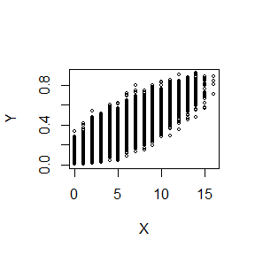

```r
    plot(xt, main="", cex=.5, xlab=bquote(X),
         ylab=bquote(Y))
```

The following are diagnose of the chain:

```r
xt1=rbind(fxy(N,x0[1,])[,1],fxy(N,x0[2,])[,1] ,fxy(N,x0[3,])[,1] ,fxy(N,x0[4,])[,1]  )
xt2=rbind(fxy(N,x0[1,])[,2],fxy(N,x0[2,])[,2] ,fxy(N,x0[3,])[,2] ,fxy(N,x0[4,])[,2]  )
psi1 <- t(apply(xt1, 1, cumsum))
psi2 <- t(apply(xt2, 1, cumsum))
for (i in 1:nrow(psi1)){psi1[i,] <- psi1[i,] / (1:ncol(psi1))
psi2[i,] <- psi2[i,] / (1:ncol(psi2))}

print(Gelman.Rubin(psi1))
```

```
## [1] 1.170995
```

```r
print(Gelman.Rubin(psi2))
```

```
## [1] 1.177305
```

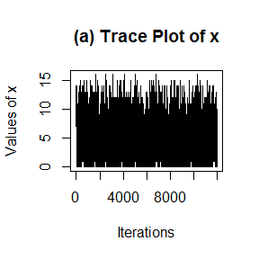

```r
erg.mean<-function(x){ # compute ergodic mean
        n<-length(x)
        result<-cumsum(x)/cumsum(rep(1,n))
      }

   par( mfrow=c(1,1))

   index<-1:N
   index2<-(b+1):N

   plot(index, xt[index,1], type='l', ylab='Values of x', xlab='Iterations', main='(a) Trace Plot of x')
```

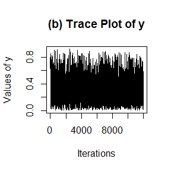

```r
   plot(index, xt[index,2], type='l', ylab='Values of y', xlab='Iterations', main='(b) Trace Plot of y')
```

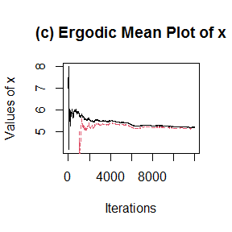

```r
   ergtheta0<-erg.mean( xt[index,1] )
   ergtheta02<-erg.mean( xt[index2,1] )
   ylims0<-range( c(ergtheta0,ergtheta02) )

   ergtheta1<-erg.mean( xt[index,2] )
   ergtheta12<-erg.mean( xt[index2,2] )
   ylims1<-range( c(ergtheta1,ergtheta12) )

   step<-10
   index3<-seq(1,N,step)
   index4<-seq(b+1,N,step)

   plot(index3 , ergtheta0[index3], type='l', ylab='Values of x', xlab='Iterations', main='(c) Ergodic Mean Plot of x')
   lines(index4, ergtheta02[index4-b], col=2, lty=2)
```

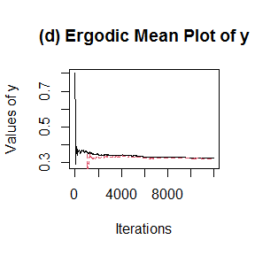

```r
   plot(index3, ergtheta1[index3], type='l', ylab='Values of y', xlab='Iterations', main='(d) Ergodic Mean Plot of y' )
   lines(index4, ergtheta12[index4-b], col=2, lty=2)
```

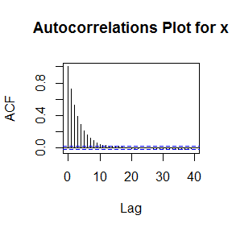

```r
   acf(xt[index2,1], main='Autocorrelations Plot for x')
```

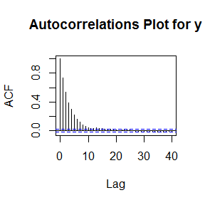

```r
   acf(xt[index2,2], main='Autocorrelations Plot for y')
```

We can find that $\hat{R}_x,\hat{R}_y$ are both less than 1.2, which means that this chain converges well.

##Homework 9

##11.3

1. Write a function to compute the kth term in
   $$\sum_{k=0}^{\infty}\frac{(-1)^k}{k!2^k}\frac{||a||^{2k+2}}{(2k+1)(2k+2)}\frac{\Gamma (\frac{d+1}{2})\Gamma (k+\frac{3}{2})}{\Gamma (k+\frac{d}{2}+1)}$$
   where $d ≥ 1$ is an integer, a is a vector in Rd, and $||.||$denotes the Euclidean norm. Perform the arithmetic so that the coefficients can be computed for (almost) arbitrarily large $k$ and $d$. (This sum converges for all $a ∈ R^d$).
2. Modify the function so that it computes and returns the sum.
3. Evaluate the sum when a = (1, 2)T .

##Answer

The kth term is:
$$\frac{(-1)^k}{k!2^k}\frac{||a||^{2k+2}}{(2k+1)(2k+2)}\frac{\Gamma (\frac{d+1}{2})\Gamma (k+\frac{3}{2})}{\Gamma (k+\frac{d}{2}+1)}=(-1)^k\exp(\ln(\frac{1}{k!2^k}\frac{||a||^{2k+2}}{(2k+1)(2k+2)}\frac{\Gamma (\frac{d+1}{2})\Gamma (k+\frac{3}{2})}{\Gamma (k+\frac{d}{2}+1)}))$$
$$=(-1)^k\exp((2k+2)\ln(||a||))+\ln(\Gamma (\frac{d+1}{2}))+\ln(\Gamma (k+\frac{3}{2}))-\sum\limits_{i=1}^k\ln(k)-k\ln2-\ln(2k+1)-\ln(2k+2)-\ln(\Gamma (k+\frac{d}{2}+1)$$

```r
kth.term=function(a,k){
  if(k!=0){d=length(a)
  a1=as.numeric(t(a)%*%a)  ##calculate ||a||^2
  s1=(k+1)*log(a1)
  s2=lgamma((d+1)/2)
  s3=lgamma(k+3/2)
  s4=sum(log(1:k))
  s5=k*log(2)
  s6=log(2*k+1)
  s7=log(2*k+2)
  s8=lgamma(k+d/2+1)
  s=s1+s2+s3-s4-s5-s6-s7-s8
  return((-1)^(k%%2)*exp(s))}
  else{return(as.numeric(t(a)%*%a)/2*gamma((length(a)+1)/2)*gamma(3/2)/gamma(length(a)/2+1))}
}
```

The examples are shown as follows:

```r
paste("When k =5, a=c(1,2) the result is",kth.term(c(1,2),5))
```

```
## [1] "When k =5, a=c(1,2) the result is -0.0109231216585281"
```

```r
paste("When k =30, a=c(1,2) the result is",kth.term(c(1,2),30))
```

```
## [1] "When k =30, a=c(1,2) the result is 6.85333004630189e-25"
```

```r
sum.term=function(a){
  s=0
  k=0
  while(abs(kth.term(a,k))>10^(-20)){
    s=s+kth.term(a,k)
    k=k+1
  }
  return(s)
}
paste("When a=c(1,2) the result is",sum.term(c(1,2)))
```

```
## [1] "When a=c(1,2) the result is 1.53216399886164"
```

##11.5

Write a function to solve the equation
$$\frac{2\Gamma (\frac{k}{2})}{\sqrt{\pi (k-1)}\Gamma (\frac{k-1}{2})}\int_{0}^{c_{k-1}}(1+\frac{u^{2}}{k-1})^{-\frac{k}{2}}du=\frac{2\Gamma (\frac{k+1}{2})}{\sqrt{\pi k}\Gamma (\frac{k}{2})}\int_{0}^{c_{k}}(1+\frac{u^{2}}{k})^{-\frac{k+1}{2}}du,$$
for a, where$c_k=\sqrt{\frac{a^2k}{k+1-a^2}}.$

Compare the solutions with the points A(k) in Exercise 11.4.

##Answer

The above equation can be expressed as
$$\exp(\ln(2\Gamma (\frac{k}{2}))-\ln(\sqrt{\pi (k-1)})-\ln(\Gamma (\frac{k-1}{2})))\int_{0}^{c_{k-1}}(1+\frac{u^{2}}{k-1})^{-\frac{k}{2}}du=\exp(\ln(2\Gamma (\frac{k+1}{2}))-\ln(\sqrt{\pi k})-\ln(\Gamma (\frac{k}{2})))\int_{0}^{c_{k}}(1+\frac{u^{2}}{k})^{-\frac{k+1}{2}}du$$

```r
f=function(k,a){
  s1.1=lgamma(k/2)+log(2)
  s1.2=log(sqrt(pi*(k-1)))
  s1.3=lgamma((k-1)/2)
  c1=sqrt(a^2*(k-1)/(k-a^2))
  f1=function(u){return((1+u^2/(k-1))^(-k/2))}
  i1=integrate(f1,lower=0,upper=c1)$value
  s2.1=lgamma((k+1)/2)+log(2)
  s2.2=log(sqrt(pi*k))
  s2.3=lgamma(k/2)
  c2=sqrt(a^2*k/(k+1-a^2))
  f2=function(u){return((1+u^2/k)^(-(k+1)/2))}
  i2=integrate(f2,lower=0,upper=c2)$value
  return(exp(s1.1-s1.2-s1.3)*i1-exp(s2.1-s2.2-s2.3)*i2)
}
```

When $k$ is set from 4 to 25, the roots are shown as follows:

```r
K =4:25
root1=numeric(22)
root2=numeric(22)
root3=numeric(22)
for(i in 1:length(K)){
  root1[i]=uniroot(function(x) f(k=K[i],x) ,c(1,min(sqrt(K[i])-0.01,2)))$root
  root2[i]=-root1[i]
}
result=cbind(K,root1,root2,root3)
x_html=knitr::kable((result),"html")
kableExtra::kable_styling(x_html,bootstrap_options = "hover",full_width = TRUE,font_size=12)
```

| K | root1 | root2 | root3 |
| --- | --- | --- | --- |
| 4 | 1.492101 | -1.492101 | 0 |
| 5 | 1.533556 | -1.533556 | 0 |
| 6 | 1.562744 | -1.562744 | 0 |
| 7 | 1.584430 | -1.584430 | 0 |
| 8 | 1.601185 | -1.601185 | 0 |
| 9 | 1.614521 | -1.614521 | 0 |
| 10 | 1.625390 | -1.625390 | 0 |
| 11 | 1.634419 | -1.634419 | 0 |
| 12 | 1.642038 | -1.642038 | 0 |
| 13 | 1.648554 | -1.648554 | 0 |
| 14 | 1.654190 | -1.654190 | 0 |
| 15 | 1.659114 | -1.659114 | 0 |
| 16 | 1.663452 | -1.663452 | 0 |
| 17 | 1.667304 | -1.667304 | 0 |
| 18 | 1.670745 | -1.670745 | 0 |
| 19 | 1.673840 | -1.673840 | 0 |
| 20 | 1.676637 | -1.676637 | 0 |
| 21 | 1.679178 | -1.679178 | 0 |
| 22 | 1.681496 | -1.681496 | 0 |
| 23 | 1.683620 | -1.683620 | 0 |
| 24 | 1.685572 | -1.685572 | 0 |
| 25 | 1.687373 | -1.687373 | 0 |

Then we do exercise 11.4

```r
S = function(a, k){
1 - pt(sqrt((a^2 *k)/(k+1-a^2)), df = k)
}
f = function(a, k){
S(a, k-1)-S(a, k)
}
A = function(k){
uniroot(function(x) S(x,k-1)-S(x,k) , c(1,min(sqrt(k)-0.01,2)))$root
}
compare.11.4 = rep(0,length(K))
for(i in 1:length(K)){compare.11.4[i] =A(K[i])}
result2=cbind(compare.11.4,root1)
x_html=knitr::kable((result2),"html")
kableExtra::kable_styling(x_html,bootstrap_options = "hover",full_width = TRUE,font_size=12)
```

| compare.11.4 | root1 |
| --- | --- |
| 1.492101 | 1.492101 |
| 1.533556 | 1.533556 |
| 1.562744 | 1.562744 |
| 1.584430 | 1.584430 |
| 1.601185 | 1.601185 |
| 1.614521 | 1.614521 |
| 1.625390 | 1.625390 |
| 1.634419 | 1.634419 |
| 1.642038 | 1.642038 |
| 1.648554 | 1.648554 |
| 1.654190 | 1.654190 |
| 1.659114 | 1.659114 |
| 1.663452 | 1.663452 |
| 1.667304 | 1.667304 |
| 1.670745 | 1.670745 |
| 1.673840 | 1.673840 |
| 1.676637 | 1.676637 |
| 1.679178 | 1.679178 |
| 1.681496 | 1.681496 |
| 1.683620 | 1.683620 |
| 1.685572 | 1.685572 |
| 1.687373 | 1.687373 |

We can find that the roots are almost the same.

## The question on PPT

Suppose $T_1, . . . , T_n$ are $i.i.d.$ samples drawn from the exponential distribution with expectation $λ$. Those values greater than $\tau$ are not observed due to right censorship, so that the observed values are $Yi = T_iI(T_i ≤ \tau ) + \tau I(T_i >\tau), i = 1, . . . , n.$ Suppose $τ$= 1 and the observed $Y_i$ values are as follows:
$$0.54, 0.48, 0.33, 0.43, 1.00, 1.00, 0.91, 1.00, 0.21, 0.85$$
Use the E-M algorithm to estimate $λ$, compare your result with the observed data MLE (note: $Y_i$ follows a mixture distribution)

##Answer

The missing data are the exact values of three samples, whose values are bigger than 1. Named as $X_1,X_2,X_3.$ Extended likelihood function is
$$l(\lambda_n,T_1...T_{10},X_1,X_2,X_3)=\frac{1}{\lambda^{10}} e^{-\frac{(3.75+X_1+X_2+X_3)}{\lambda}}$$
$$l_0(\lambda,T_1...T_n)=E[\ln l(\lambda,T_1...T_{10},X_1,X_2,X_3)|T_1...T_{10}]$$
$$= E[-10\ln\lambda-\frac{(3.75+X_1+X_2+X_3)}{\lambda}|T_1...T_{10}]=-10\ln\lambda-\frac{(3.75+3\int_1^\infty\frac{x}{\lambda_n}e^{-\frac{x}{\lambda_n}}dx)}{\lambda \int_1^\infty\frac{x}{\lambda_n}e^{-\frac{1}{\lambda_n}}dx}$$
$$=-10\ln\lambda-\frac{3.75}{\lambda}-\frac{3(1+\lambda_n)}{\lambda}$$
$$\frac{\partial }{\partial \lambda}\ln l_0(\lambda,T_1...T_n)=-\frac{10}{\lambda}+\frac{3.75+3(1+\lambda_n)}{\lambda^2}=0$$
$$\lambda_{n+1}=\frac{3.75+3(1+\lambda_n)}{10}$$
It is clear that $\left \{\lambda_n \right \}$ is monotone. Using monotone convergence theorem, we can prove that $\left \{ \lambda_n \right \}$ converge to $\frac{6.75}{7}\approx 0.964$.

The likelihood function can be written as follows:
$$l(T_1...T_n|\lambda)=\lambda^{7} e^{-\lambda(0.54+0.48+0.33+0.43+0.91+0.21+0.85)}(\int_1^\infty\frac{1}{\lambda}_ne^{-\frac{x}{\lambda_n}}dx)^3=\frac{1}{\lambda^{7}} e^{-\frac{6.75}{\lambda}}$$
$$\frac{\partial }{\partial \lambda}\ln(l(T_1...T_n|\lambda))=-\frac{7}{\lambda}+\frac{6.75}{\lambda^2}=0$$
$$MLE~of~\lambda=\frac{6.75}{7}\approx 0.964$$

##Homework 10

##Page 204 1

Why are the following two invocations of lapply() equivalent? trims <- c(0, 0.1, 0.2, 0.5) x <- rcauchy(100) lapply(trims, function(trim) mean(x, trim = trim)) lapply(trims, mean, x = x)

##Answer

```r
trims <- c(0, 0.1, 0.2, 0.5)
x <- rcauchy(100)
lapply(trims, function(trim) mean(x, trim = trim))
```

```
## [[1]]
## [1] 9.869087
##
## [[2]]
## [1] 0.2472091
##
## [[3]]
## [1] 0.2286372
##
## [[4]]
## [1] 0.2124546
```

```r
lapply(trims, mean, x = x)
```

```
## [[1]]
## [1] 9.869087
##
## [[2]]
## [1] 0.2472091
##
## [[3]]
## [1] 0.2286372
##
## [[4]]
## [1] 0.2124546
```

For the first invocation, it means applying function(trim){mean(x, trim = trim)} to the every elements in the trims. The result is a list of the same length of trims, whose $i$ th element is mean(x-trims[i]).

For the second invocation, the arguments in lapply() behind the func represent the arguments in func(). In this case, mean() has two arguments: x and trim. Since x is pointed, the trims are pointed to the values of trim. Therefore, the second invocation has the same meaning as the first one.

##Page 204 5

For each model in the previous two exercises, extract $R^2$ using the function below. rsq <- function(mod) summary(mod)$r.squared

##Answer

Extract $R^2$ from Question 3:

```r
formulas = list(
  mpg ~ disp,
  mpg ~ I(1 / disp),
  mpg ~ disp + wt,
  mpg ~ I(1 / disp) + wt
)
rsq <- function(mod) summary(mod)$r.squared
result3 = lapply(formulas, function(f) lm(data = mtcars, formula = f))

lapply(result3,rsq)
```

```
## [[1]]
## [1] 0.7183433
##
## [[2]]
## [1] 0.8596865
##
## [[3]]
## [1] 0.7809306
##
## [[4]]
## [1] 0.8838038
```

Extract $R^2$ from Question 4:

```r
bootstraps <- lapply(1:10, function(i) {
rows <- sample(1:nrow(mtcars), rep = TRUE)
mtcars[rows, ]
})
result4=lapply(bootstraps,function(data)lm(data=data,formula=mpg ~ disp))
lapply(result4,rsq)
```

```
## [[1]]
## [1] 0.6336193
##
## [[2]]
## [1] 0.7925795
##
## [[3]]
## [1] 0.7128142
##
## [[4]]
## [1] 0.7812823
##
## [[5]]
## [1] 0.7564151
##
## [[6]]
## [1] 0.7476029
##
## [[7]]
## [1] 0.7559344
##
## [[8]]
## [1] 0.6268031
##
## [[9]]
## [1] 0.6339284
##
## [[10]]
## [1] 0.7424729
```

##Page 213 1

Use vapply() to: a) Compute the standard deviation of every column in a numeric data frame. b) Compute the standard deviation of every numeric column in a mixed data frame. (Hint: you’ll need to use vapply() twice.)

##Answer

The first function is to compute the standard deviation of every column in mtcars.

```r
colsd=function(x){
  locus=1:length(x)
  vapply(locus,function(i)sd(x[[i]]),numeric(1))
}
colsd(mtcars)
```

```
##  [1]   6.0269481   1.7859216 123.9386938  68.5628685   0.5346787   0.9784574
##  [7]   1.7869432   0.5040161   0.4989909   0.7378041   1.6152000
```

The second function is to compute the standard deviation of every numeric column in list2.

```r
colsdmix=function(x){
  locus1=1:length(x)
  locus2=vapply(locus1,function(i)is.numeric(x[[i]]),numeric(1))
  locus3=seq(along=locus2)[locus2==TRUE]
  vapply(locus3,function(i)sd(x[[i]]),numeric(1))
}
list2=list(list("a","b","c"),c(rnorm(10)),c(rbinom(10,5,0.5)))
colsdmix(list2)
```

```
## [1] 0.9261791 0.8755950
```

##Page 214 7

Implement $mcsapply()$, a multicore version of $sapply()$. Can you implement $mcvapply()$, a parallel version of $vapply()$? Why or why not?

```r
library(parallel)
## repeat Page 204 Question 5
cl <- makeCluster(mc <- getOption("cl.cores", 4))
rsq <- function(mod) summary(mod)$r.squared
clusterExport(cl=cl, varlist=c("rsq"))
##redo Page 204 Question 3
parSapply(cl, bootstraps, function(x) rsq(lm(data = x, formula = mpg ~ disp)))
```

```
##  [1] 0.6336193 0.7925795 0.7128142 0.7812823 0.7564151 0.7476029 0.7559344
##  [8] 0.6268031 0.6339284 0.7424729
```

```r
##Page 204 Question 4
parSapply(cl, formulas, function(f) rsq(lm(data =mtcars, formula = f)))
```

```
## [1] 0.7183433 0.8596865 0.7809306 0.8838038
```

I can not find either mcvapply or parVapply, so I can not implement them.

##Homework 11

##9.8

This example appears in [40]. Consider the bivariate density
$$f(x,y)\propto \binom{n}{x}y^{x+a-1}(1-y)^{n-x+b-1},~x=0,1,...n,~0\leqslant y\leqslant 1$$
It can be shown (see e.g. [23]) that for fixed $a, b, n$, the conditional distributions are Binomial($n, y$) and Beta($x + a, n − x + b$). Use the Gibbs sampler to generate a chain with target joint density f($x, y$).

(1).Write an Rcpp function for Exercise 9.8 (page 278, Statistical Computing with R).

(2).Compare the corresponding generated random numbers with pure R language using the function “qqplot”.

(3).Campare the computation time of the two functions with the function “microbenchmark”.

(4).Comments your results.

##Answer

Without generality, we set $n=20~, a=4, ~b=2.$

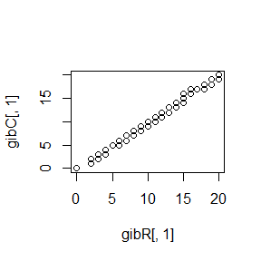

```r
library(Rcpp)
library(microbenchmark)
set.seed(123)
cppFunction('NumericMatrix gibbsC(int N, int thin, int n, int a, int b) {
  NumericMatrix mat(N, 2);
  double x = 0, y = 0;
  for(int i = 0; i < N; i++) {
    for(int j = 0; j < thin; j++) {
      x = rbinom(1, n, y)[0];
      y = rbeta(1, (x+a), (n-x+b))[0];
    }
    mat(i, 0) = x;
    mat(i, 1) = y;
  }
  return(mat);
}')
gibbsR <- function(N, thin,n,a,b) {
  mat <- matrix(nrow = N, ncol = 2)
  x <- y <- 0
  for (i in 1:N) {
    for (j in 1:thin) {
      x <- rbinom(1, n, y)
      y <- rbeta(1, (x+a), (n-x+b))
    }
    mat[i, ] <- c(x, y)
  }
  mat
}


gibR=gibbsR(1000,10,20,4,2)
gibC=gibbsC(1000,10,20,4,2)

qqplot(gibR[,1],gibC[,1])
```

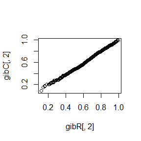

```r
qqplot(gibR[,2],gibC[,2])
```

```r
ts <- microbenchmark(gibbR=gibbsR(1000,10,20,4,2),
gibbC=gibbsC(1000,10,20,4,2))
summary(ts)[,c(1,3,5,6)]
```

```
##    expr        lq    median       uq
## 1 gibbR 53.783529 56.285755 62.94363
## 2 gibbC  4.011606  4.214367  5.22987
```

We can draw a conclusion that gibbsR and gibbsC have the same function, while gibbsC is much faster than gibbsR.